# Análisis de los vuelos internacionales en R

Series de tiempo | Licenciatura en Estadística | FCEyE | UNR

Profesores: Fernanda Méndez, Facundo Sigal

# 1 Introducción y Objetivo

El transporte aéreo internacional es un sector clave para la economía global, ya que conecta países, facilita el comercio, el turismo y los intercambios culturales. En particular, las empresas estadounidenses desempeñan un papel central en este mercado debido a la magnitud de su red de destinos y a la demanda constante de viajes hacia y desde Estados Unidos. Sin embargo, este tipo de actividad está sujeta a variaciones estacionales como, por ejemplo, vacaciones o a eventos imprevistos que pueden afectar el tráfico aéreo.

Por eso en este trabajo se busca identificar patrones que ayuden a comprender el comportamiento del sector con el objetivo de pronosticar futuras cantidades de vuelos para ayudar a la toma de decisiones futuras.

# 2 Materiales

```r
# Carga de librerias

library(tsibble)
library(dplyr)
library(tidyverse)
library(ggplot2)
library(feasts)
library(fable)     # para trabajar con objetos tsibble
library(patchwork) # presentar graficos uno al lado del otro
library(broom)     # IC de los parametros

options(scipen = 999)
```

```r
# Carga de datos

d <- readr::read_csv("USA Airline Traffic Data completo.csv") |>
  select(Year, Month, Int_Flt) |>
  filter(Year >= 2004, Year <= 2013) |>
  mutate(Fecha = yearmonth(paste(Year, Month, sep = "-"))) |>
  select(-Year, -Month) |>
  as_tsibble(index = Fecha)
```

```r
# Creamos un data sin las ultimas 5 obs (Ago, Sep, Oct, Nov y Dic 2013)

d_train <- d |>
  filter(Fecha < yearmonth("2013-08"))
```

# 3 Descriptivo

La serie tiene periodicidad mensual.

## 3.1 Test Ljung-Box

Se realiza el test de Ljung-Box para analizar si la serie de interés se comporta como un ruido blanco. Se plantean las siguietnes hipótesis:

$H_0)$ $\rho_1 = \dots = \rho_k = 0 \quad \quad k \in \{6, 12, 18, 24\}$

$H_1)$ Al menos un $\rho_i$ es distinto de cero. $\quad i=\overline{1,k}$

```r
map_dfr(c(6, 12, 18, 24), \(l) {
  d_train |>
    features(Int_Flt, ljung_box, lag = l) |>
    mutate(lag = l)
}) |>
  select(lag, everything()) |> # Para que el 'lag' sea la primer columna
  knitr::kable(
    caption = "Pruebas Ljung-Box",
    col.names = c("k", "Estadística", "p-value"),
    digits = 4,
    align = "c"
  )
```

Pruebas Ljung-Box

| k | Estadística | p-value |
| --- | --- | --- |
| 6 | 37.0172 | 0 |
| 12 | 119.4842 | 0 |
| 18 | 154.0637 | 0 |
| 24 | 210.7870 | 0 |

Con un nivel de significación del 5% y en base a la evidencia muestral, se rechaza la hipótesis nula de ausencia de autocorrelación, para los cuatro rezagos considerados ($p-value < 0.001$). Consecuentemente, la serie presenta dependencia temporal y no puede modelarse como ruido blanco. Esto justifica continuar con el análisis de su estructura temporal.

## 3.2 Evolución del número de vuelos

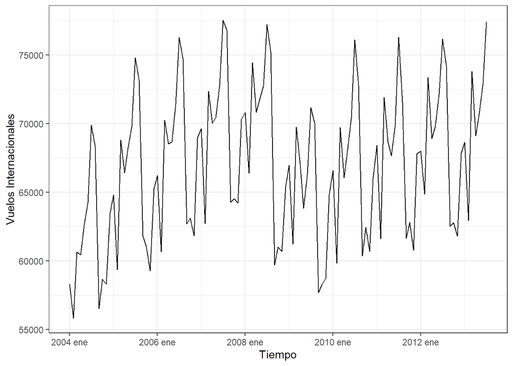

```r
d_train |>
  autoplot(Int_Flt) +
  labs(x = "Tiempo",
       y = "Vuelos Internacionales") +
  theme_bw()
```

En los períodos 2004-2008 y 2009-2013, la serie parece tener una tendencia a crecer. A mediados de 2008 ocurre una baja, que puede interpretarse como un valor atípico.

En el segundo semestre del 2009, hay un mes en el que se observa un bajo número de vuelos, es casi tan bajo como el número de vuelos al comienzo de la serie. Este valor también puede ser interpretado como un *outlier*.

## 3.3 Estacionalidad

### 3.3.1 Comportamiento anual del número de vuelos

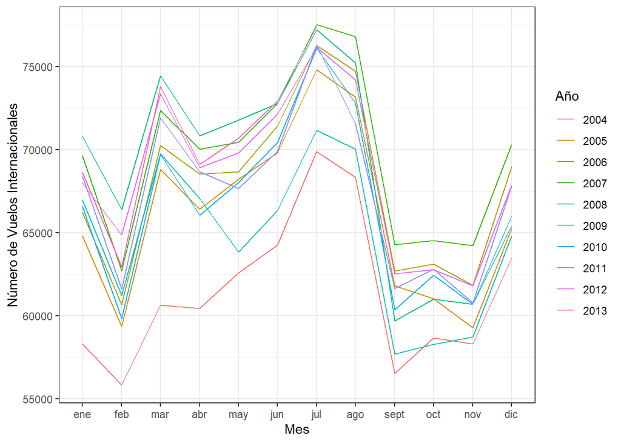

```r
d_train |>
  mutate(
    mes = month(Fecha, label = TRUE, abbr = TRUE), # abbr=T abrevia meses
    anio = year(Fecha)
  ) |>
  ggplot(aes(x = mes, y = Int_Flt,
             group = anio, color = factor(anio))) +
  geom_line() +
  labs(
    x = "Mes",
    y = "Número de Vuelos Internacionales",
    color = "Año"
  ) +
  theme_bw()
```

El 2004 parece presentar valores más bajos que el resto de los años, puede deberse a la leve tendencia a crecer de la serie en los años 2004-2008 anteriormente destacada. También se observan valores levemente bajos en algunos meses del 2009, reflejando el segundo período (2009-2013) con aparente tendencia a crecer luego de la baja del 2008.

### 3.3.2 Comportamiento mensual del número de vuelos

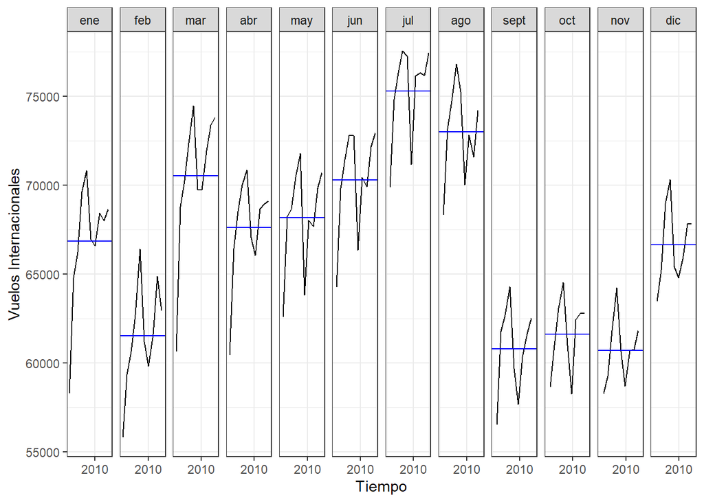

```r
d_train |>
  gg_subseries(Int_Flt) +
  labs(x = "Tiempo",
       y = "Vuelos Internacionales") +
  scale_x_yearmonth(date_breaks = "7 years", date_labels = "%Y") +
  theme_bw()
```

En promedio, los meses en que menos vuelos se venden son Febrero, Septiembre, Octubre y Noviembre. En los que más se venden son Julio y Agosto. Este fénomeno probablemente sea debido a que los estadounidenses reservan vuelos para tomar vacaciones en los meses de verano.

De manera general, en todos los años parece presentarse el mismo comportamiento observándose un patrón estacional estable.

## 3.4 Distribución de la cantidad de vuelos por año

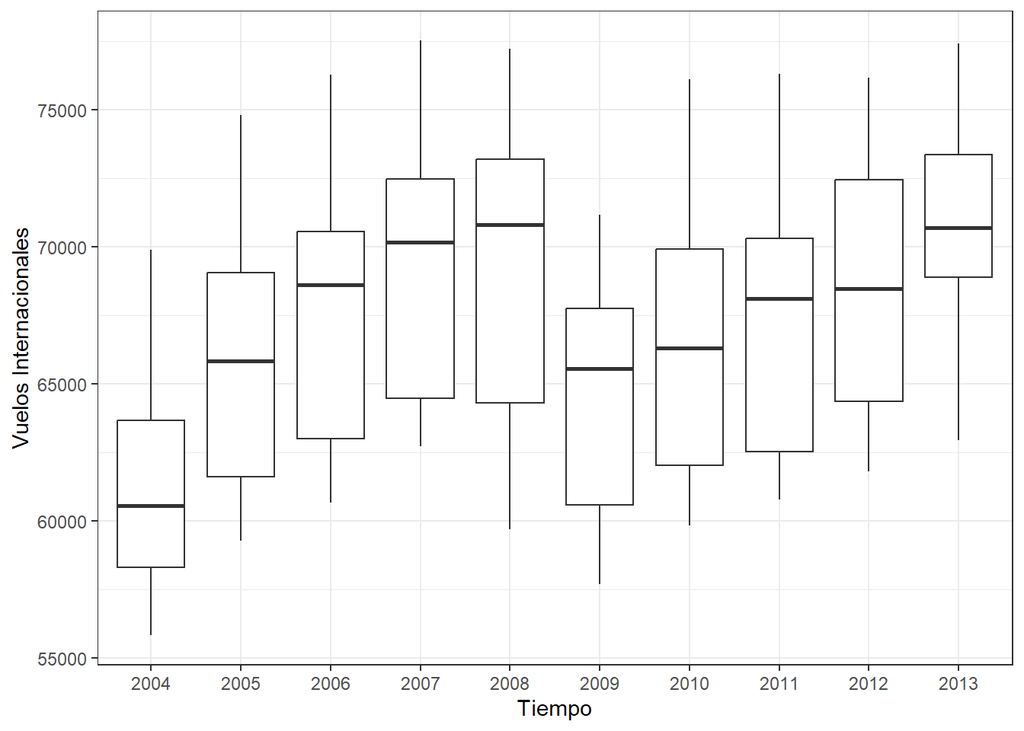

```r
d_train |>
  mutate(Año = factor(year(Fecha))) |>
  ggplot() +
    aes(x = Año, y = Int_Flt) +
    geom_boxplot() +
    labs(x = "Tiempo",
         y = "Vuelos Internacionales") +
    theme_bw()
```

Por un lado, la cantidad mediana de vuelos anual parece ir aumentando con el correr de los años en los períodos 2004-2008 y 2009-2013. Esto se condice con las leves tendencias crecientes vistas anteriormente. Se observa también una baja entre el número mediano de vuelos del 2008 y el del 2009, reflejando el mencionado cambio de nivel ocurrido en 2008.

Por otro lado, parece que los números de vuelos vendidos en los meses varían similarmente en todos los años, es decir, la variancia de la serie parece ser constante a través del tiempo.

## 3.5 Relación entre el número medio de vuelos y el desvío de los vuelos por año

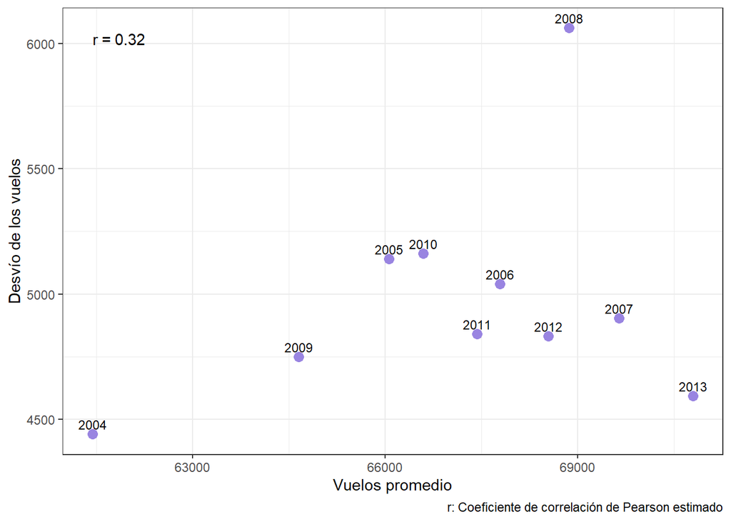

```r
d_train |>
  index_by(Año = year(Fecha)) |>  # index_by = group_by (por el tsibble)
  summarise(media = mean(Int_Flt),
            desvio = sd(Int_Flt)) |>
  ggplot() +
    aes(x = media, y = desvio, label = Año) +
    geom_point(color = "#9984E1", size = 3) +
    geom_text(vjust = -0.5, size = 3) +
    ggpubr::stat_cor(aes(label = paste("r", after_stat(r), # agrego r
                                       sep = " ~ '=' ~ ")),
                     method = "pearson",
                     label.x.npc = "left",
                     label.y.npc = "top") +
    labs(x = "Vuelos promedio",
         y = "Desvío de los vuelos",
         caption = "r: Coeficiente de correlación de Pearson estimado") +
    theme_bw()
```

Sin tener en cuenta el 2008, a medida que el promedio de vuelos aumenta, el desvío de los vuelos parece mantenerse relativamente constante ($r=0.32$). Esto sugiere que la cantidad de vuelos media no parece guardar relación con el desvío de los vuelos, y consecuentemente con la variancia de los mismos. Este resultado junto al anterior, indican que no sería necesario estabilizar la variancia de la serie aplicando transformaciones como las de Box-Cox o logarítimicas a la hora de ajustar modelos.

Considerando todo lo expuesto, la serie parece ser no estacionaria en media, presentar pauta estacional y ser estacionaria en variancia.

Para describir el comportamiento de las autocorrelaciones se presentan la Función de autocorrelación muestral (FACM) y la Función de autocorrelación parcial muestral (FACPM) del número de vuelos.

## 3.6 FACM del número de vuelos

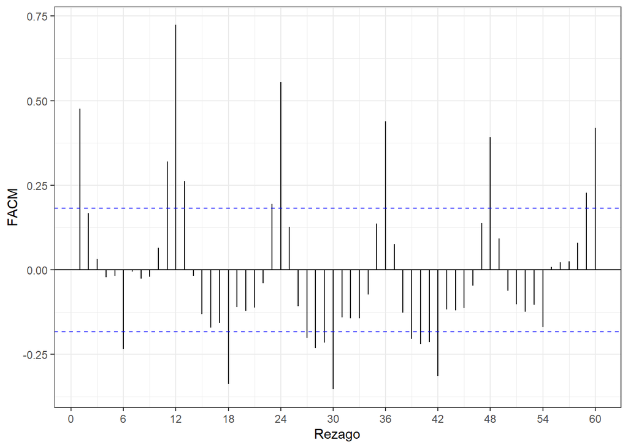

```r
d_train |>
  ACF(Int_Flt, lag_max = 60) |>
  autoplot() +
  labs(x = "Rezago",
       y = "FACM") +
  theme_bw()
```

## 3.7 FACPM del número de vuelos

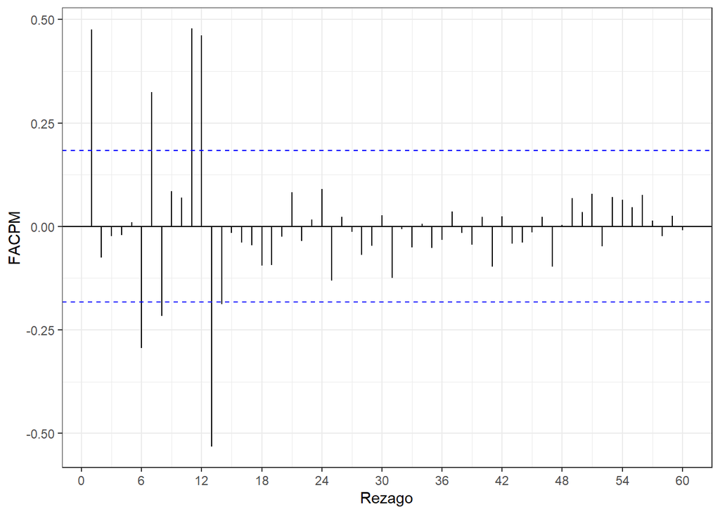

```r
d_train |>
  PACF(Int_Flt, lag_max = 60) |>
  autoplot() +
  labs(x = "Rezago",
       y = "FACPM") +
  theme_bw()
```

En la FACM, los coeficientes estimados de los rezagos 12, 24, 36, 48, etc, presentan valores significativos altos y van decayendo lentamente. Esto se condice con lo anteriormente mencionado de que la serie tiene, teniendo en cuenta que la periodicidad de la serie es mensual, aparentemente, una componente estacional marcada.

Dada esta no estacionariedad en la parte estacional de la serie, se continúa el trabajo analizando las características de la primera diferencia estacional.

## 3.8 FACM de la primer diferencia estacional

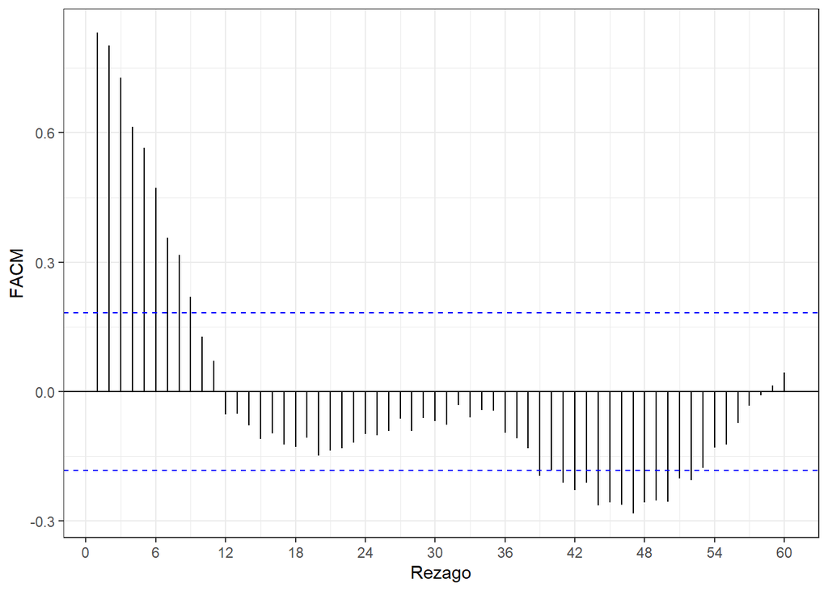

```r
d_train |>
  mutate(dif_estacional = difference(Int_Flt, lag = 12)) |>
  ACF(dif_estacional, lag_max = 60) |>
  autoplot() +
  labs(
    x = "Rezago",
    y = "FACM"
  ) +
  theme_bw()
```

## 3.9 FACPM de la primer diferencia estacional

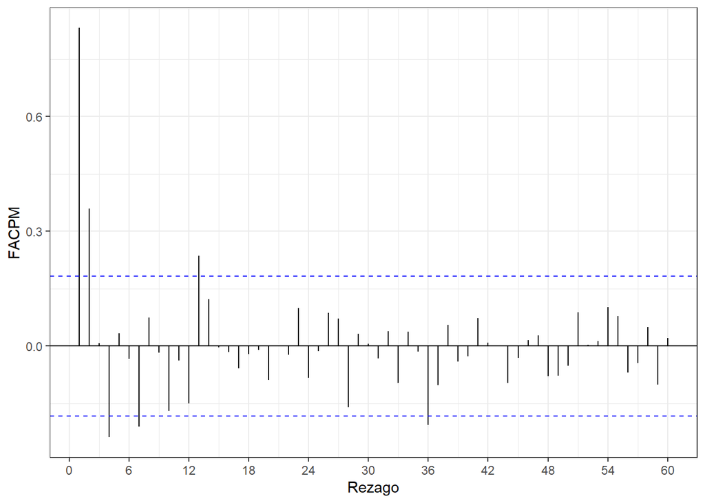

```r
d_train |>
  mutate(dif_estacional = difference(Int_Flt, lag = 12)) |>
  PACF(dif_estacional, lag_max = 60) |>
  autoplot() +
  labs(
    x = "Rezago",
    y = "FACPM"
  ) +
  theme_bw()
```

En la parte estacional de la FACM de la serie diferenciada, sólo el bastón del rezago 48 es significativo. Esto quiere decir que se logró la estacionariedad en la parte estacional.

Los coeficientes estimados de la parte regular, de la FACM de la primera diferencia estacional, son significativos y parecen ir decayendo lentamente, sugiriendo que la parte regular tampoco es estacionaria. Esto podría deberse a las tendencias crecientes observadas con anterioridad.

Acorde a esto, también se analiza qué ocurre si también se toma una diferencia regular.

## 3.10 FACM de la primera diferencia estacional y regular

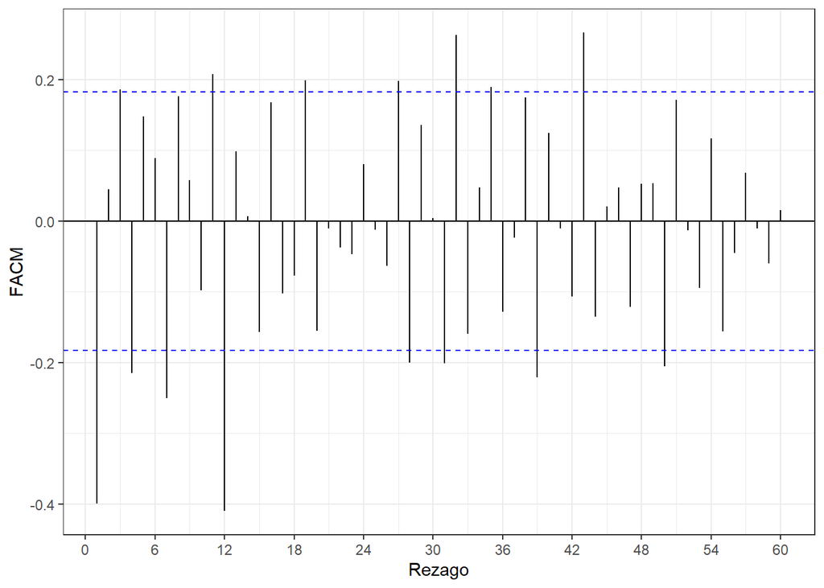

```r
d_train |>
  mutate(
    dif_doble = Int_Flt |>
      difference(lag = 12) |>  # dif estacional
      difference()             # dif regular
  ) |>
  ACF(dif_doble, lag_max = 60) |>
  autoplot() +
  labs(
    x = "Rezago",
    y = "FACM"
  ) +
  theme_bw()
```

## 3.11 FACPM de la primera diferencia estacional y regular

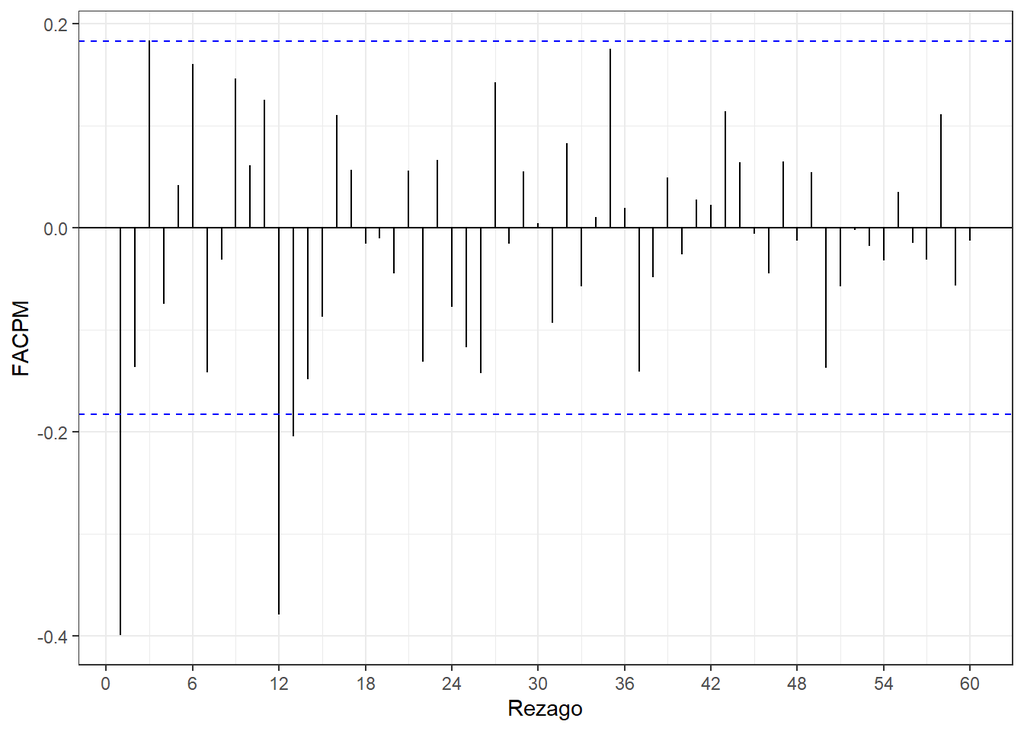

```r
d_train |>
  mutate(
    dif_doble = Int_Flt |>
      difference(lag = 12) |>  # dif estacional
      difference()             # dif regular
  ) |>
  PACF(dif_doble, lag_max = 60) |>
  autoplot() +
  labs(
    x = "Rezago",
    y = "FACPM"
  ) +
  theme_bw()
```

En la FACM de la serie con ambas diferencias, en la parte estacional sólo se observa un bastón significativo que corresponde al rezago 12 y en la parte regular se observan tres significativos. De esto de desprende que estos dos recursos conducen a la estacionariedad tanto en la parte regular como en la estacional.

# 4 Especificación del modelo

Para la parte estacional ma1 porq solo sobrevivio un baston, el del 12 en acf dif dif

## 4.1 Postulación de posibles modelos

Se tienen en cuenta las características observadas en el análisis descriptivo, como la presencia de estacionalidad, a la hora de postular modelos que permitan cumplir con el objetivo del análisis.

En la FACM de las diferencias, se observa que sólo el coeficiente del rezago 12 es significativo. Por este motivo se emplea una estructura $MA(1)$ para la parte estacional.

En la parte regular hay tres bastones significativos, asociados a los rezagos uno, cuatro y siete. Sin embargo, los últimos dos presentan magnitudes bajas en comparación con el primero. Esto conduce a dos alternativas. La primera es ajustar una estructura $MA(1)$. La segunda alternativa es ajustar un modelo $ARMA(1,1)$ porque teniendo en cuenta los tres bastones significativos de la FACM y que sólo el primero de la FACPM es significativo, también podría estar sugiriendo un proceso autorregresivo. Es decir que los modelos a ajustar son:

- Modelo 1: $SARIMA(0,1,1)(0,1,1)_{12}$
- Modelo 2: $SARIMA(1,1,1)(0,1,1)_{12}$

Además de estos dos últimos, se ajustará el modelo sugerido por el proceso automático implementado en la función `ARIMA()`.

```r
modelo_a <- d_train |>
  model(arima_fit = ARIMA(Int_Flt))

report(modelo_a)
```

```
Series: Int_Flt
Model: ARIMA(1,0,3)(0,1,1)[12]

Coefficients:
         ar1      ma1     ma2     ma3     sma1
      0.9774  -0.4277  0.1150  0.2110  -0.7428
s.e.  0.0326   0.1087  0.1234  0.1254   0.1211

sigma^2 estimated as 1345852:  log likelihood=-875.96
AIC=1763.92   AICc=1764.8   BIC=1779.73
```

Este último es el modelo $SARIMA(1,0,3)(0,1,1)_{12}$ que es denominado Modelo A.

## 4.2 Diagnosis de los modelos

Una vez propuestos los modelos, se analiza cuáles cumplen los supuestos.

### 4.2.1 Modelo 1

Viene dado por:

$$(1-B)(1-B^{12})z_t =(1 - \theta_1B)(1 - \Theta_1B^{12}) a_t$$

```r
# ajuste del modelo
modelo_1 <- d_train |>
  model(m1 = ARIMA(Int_Flt ~ pdq(0,1,1) + PDQ(0,1,1, period = 12)))
```

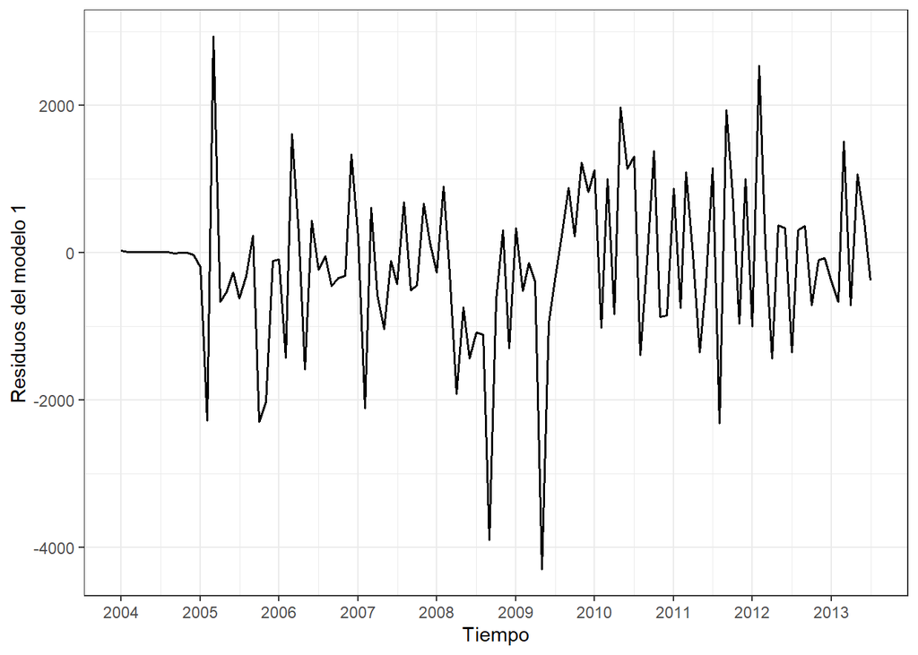

```r
# grafico de residuos vs t: a_t^ vs t

modelo_1 |>  # augment() añade los residuos automáticamente
  augment() |>
  ggplot(aes(x = Fecha, y = .innov)) +  # .innov son los residuos del modelo
  geom_line(color = "black", linewidth = 0.7) +
  scale_x_yearmonth(date_breaks = "1 year", date_labels = "%Y") +
  labs(x = "Tiempo", y = "Residuos del modelo 1") +
  theme_bw()
```

La inspección visual del gráfico sugiere que los residuos del modelo 1 tendrían media cero y variancia constante.

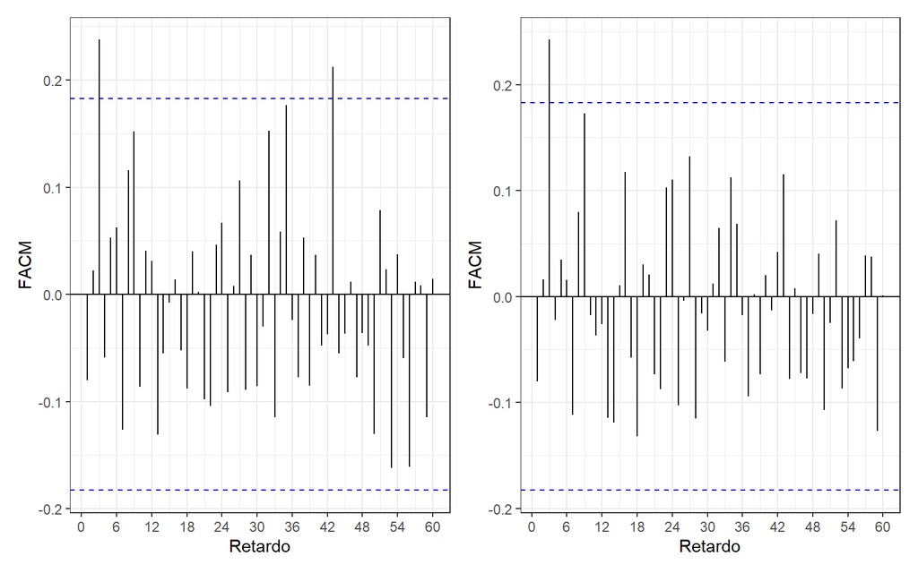

```r
# ACF de residuos modelo 1
acf_modelo_1 <- modelo_1 |>
  augment() |>
  ACF(.innov, lag_max = 60) |>
  autoplot() +
  labs(x = "Retardo", y = "FACM", title = NULL) +
  theme_bw()

# PACF de residuos modelo 1
pacf_modelo_1 <- modelo_1 |>
  augment() |>
  PACF(.innov, lag_max = 60) |>
  autoplot() +
  labs(x = "Retardo", y = "FACM", title = NULL) +
  theme_bw()

acf_modelo_1 + pacf_modelo_1
```

```r
# ljung-box para residuos modelo 1
# Ho) p1 = ... = p20 = 0 , p=0.27 --> residuos = RB

pv_ljung_modelo_1 <- modelo_1 |>
  augment() |>
  features(.innov, ljung_box, lag = 20, dof = 2) |>  # dof = degrees of freedom = # parametros^
  pull(lb_pvalue)

pv_ljung_modelo_1
```

```
[1] 0.2718211
```

Por este motivo, se utiliza un recurso que evalúe a todos los primeros coeficientes de la FAC de manera conjunta. Se realiza el test de Ljung-Box y se concluye en base a la evidencia muestral que los primeros 20 coeficientes de los residuos del modelo son nulos conjuntamente, es decir, los residuos del modelo 1 son ruido blanco a un 5% de significación ($p-value=$ 0.2718211). Se cumple el supuesto de residuos incorrelados.

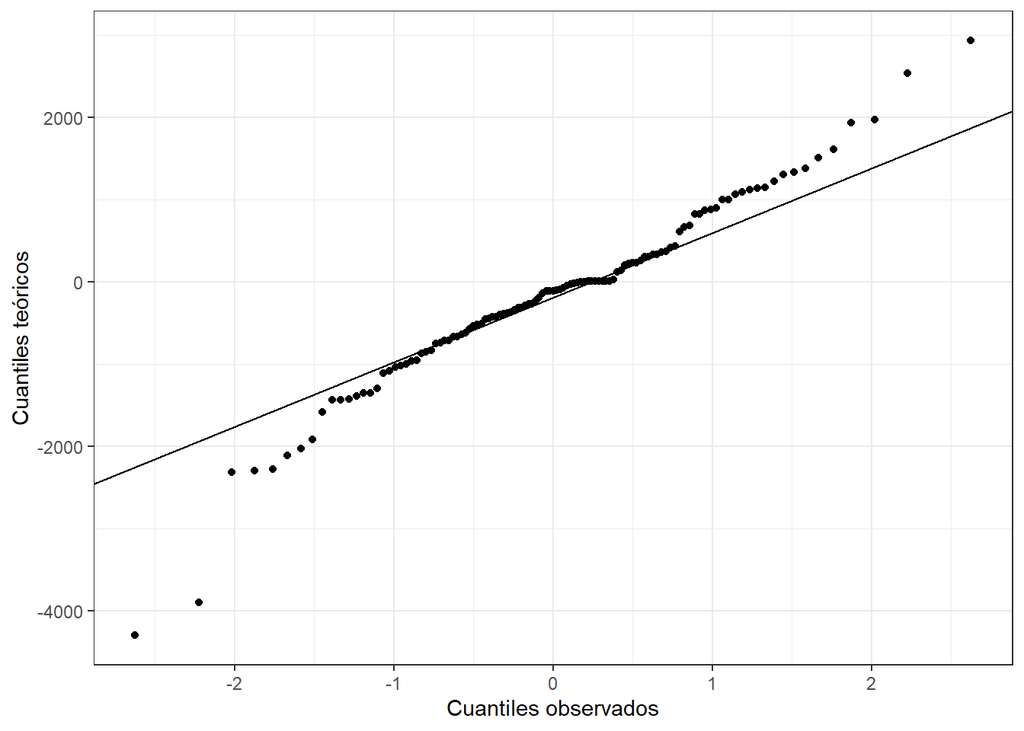

```r
# QQplot residuos modelo 1
modelo_1 |>
  augment() |>
  ggplot(aes(sample = .innov)) +
  stat_qq() +
  stat_qq_line() +
  labs(y = "Cuantiles teóricos", x = "Cuantiles observados") +
  theme_bw()
```

A partir de la visualización del gráfico cuantil-cuantil, los puntos no parecen ubicarse sobre una línea lo cual podría estar sugiriendo que los residuos no siguen una distribución normal.

```r
# test normalidad sobre residuos modelo 1
# Ho) residuos tienen distribucion normal

residuos_modelo_1 <- modelo_1 |>
  augment() |>
  pull(.innov)  # o .resid

shapiro_modelo_1 <- shapiro.test(residuos_modelo_1)
pv_shapiro_modelo_1 <- shapiro_modelo_1$p.value


shapiro_modelo_1
```

```
    Shapiro-Wilk normality test

data:  residuos_modelo_1
W = 0.96385, p-value = 0.0034
```

Se realiza la prueba de Shapiro-Wilk y se concluye en base a la evidencia muestral que los residuos del modelo 1 no siguen una distribución normal a un 5% de significación ($p-value=$ 0.0034003).

```r
# parametros estimados junto a p_value q evalua
# Ho) parametro = 0
tidy(modelo_1) |>
  select(term, estimate, std.error, p.value)
```

```
# A tibble: 2 × 4
  term  estimate std.error      p.value
  <chr>    <dbl>     <dbl>        <dbl>
1 ma1     -0.384    0.0757 0.00000181
2 sma1    -0.706    0.116  0.0000000218
```

Según los resultados de la tabla, se concluye que ambos parámetros del modelo 1, $\theta_1$ y $\Theta_1$ son no nulos, al 5 % de nivel de significación y en base a la evidencia muestral. En otras palabras, el modelo 1 cumple el supuesto de parsimonia.

```r
fit_1 <- modelo_1$m1[[1]]$fit$model   # objeto Arima
cov2cor(fit_1$var.coef)
```

```
            ma1       sma1
ma1   1.0000000 -0.0116207
sma1 -0.0116207  1.0000000
```

Según la matriz de correlaciones, se estima que $\hat{corr}(\theta_1, \Theta_1) = -0.0116$ lo cual permitiría concluir que los parámetros del modelo 1 no son redundantes porque están prácticamente incorrelados.

```r
coef(modelo_1) |>
  select(.model, term, estimate, std.error)
```

```
# A tibble: 2 × 4
  .model term  estimate std.error
  <chr>  <chr>    <dbl>     <dbl>
1 m1     ma1     -0.384    0.0757
2 m1     sma1    -0.706    0.116
```

Acorde a la tabla se observa que la estimación para el parámetro del modelo 1, $\theta_1$, es menor a uno en valor absoluto, lo cual conlleva a concluir que el modelo 1 es invertible en la parte regular. Análogamente ocurre con el parámetro $\Theta_1$, permitiendo concluir que el modelo 1 también es invertible en la parte estacional. Por estas razones el modelo 1 es admisible.

### 4.2.2 Modelo 2

Viene dado por:

$$(1-\phi_1B)(1-B)(1-B^{12})z_t =(1 - \theta_1B)(1 - \Theta_1B^{12}) a_t$$

```r
# ajuste del modelo
modelo_2 <- d_train |>
  model(m2 = ARIMA(Int_Flt ~ pdq(1,1,1) + PDQ(0,1,1, period = 12)))
```

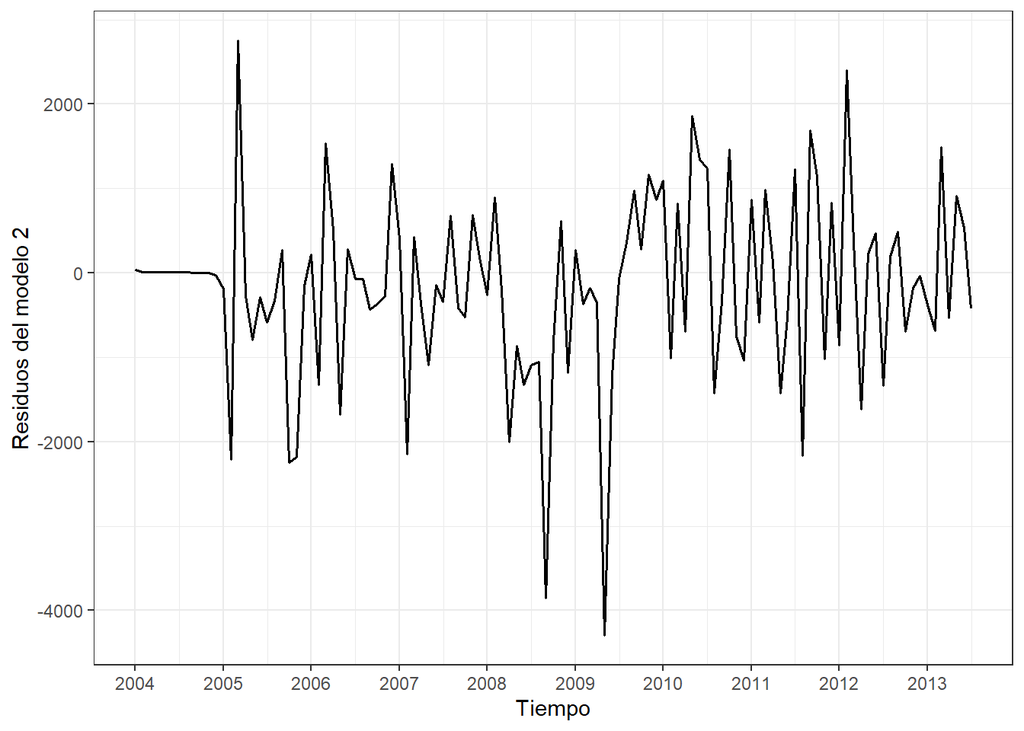

```r
# grafico de residuos vs t: a_t^ vs t

modelo_2 |>
  augment() |>
  ggplot(aes(x = Fecha, y = .innov)) +
  geom_line(color = "black", linewidth = 0.7) +
  scale_x_yearmonth(date_breaks = "1 year", date_labels = "%Y") +
  labs(x = "Tiempo", y = "Residuos del modelo 2") +
  theme_bw()
```

La inspección visual del gráfico sugiere que los residuos del modelo 2 tendrían media cero y variancia constante.

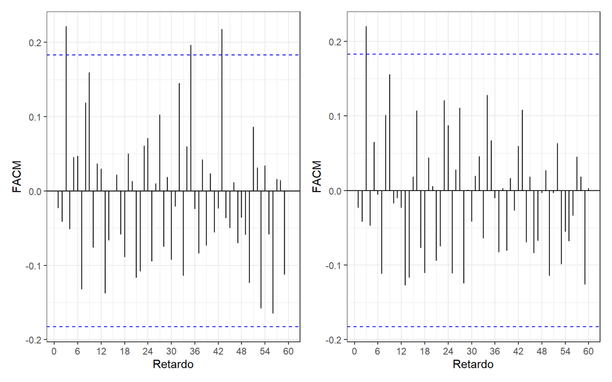

```r
# ACF de residuos modelo 2
acf_modelo_2 <- modelo_2 |>
  augment() |>
  ACF(.innov, lag_max = 60) |>
  autoplot() +
  labs(x = "Retardo", y = "FACM", title = NULL) +
  theme_bw()

# PACF de residuos modelo 2
pacf_modelo_2 <- modelo_2 |>
  augment() |>
  PACF(.innov, lag_max = 60) |>
  autoplot() +
  labs(x = "Retardo", y = "FACM", title = NULL) +
  theme_bw()

acf_modelo_2 + pacf_modelo_2
```

```r
# ljung-box para residuos modelo 2
# Ho) p1 = ... = p20 = 0 , p=0.25 --> residuos = RB

pv_ljung_modelo_2 <- modelo_2 |>
  augment() |>
  features(.innov, ljung_box, lag = 20, dof = 3) |>
  pull(lb_pvalue)

pv_ljung_modelo_2
```

```
[1] 0.2574427
```

Por este motivo, se utiliza un recurso que evalúe a todos los primeros coeficientes de la FAC de manera conjunta. Se realiza el test de Ljung-Box y se concluye en base a la evidencia muestral que los primeros 20 coeficientes de los residuos del modelo son nulos conjuntamente, es decir, los residuos del modelo 2 son ruido blanco a un 5% de significación ($p-value=$ 0.2574427). Se cumple el supuesto de residuos incorrelados.

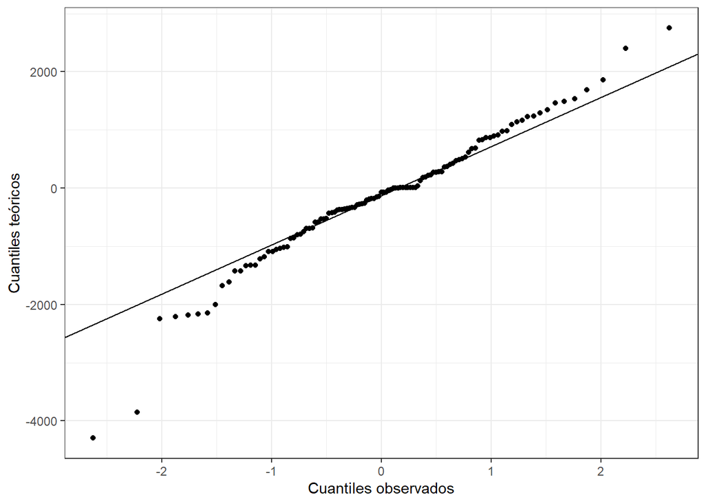

```r
# QQplot residuos modelo 2
modelo_2 |>
  augment() |>
  ggplot(aes(sample = .innov)) +
  stat_qq() +
  stat_qq_line() +
  labs(y = "Cuantiles teóricos", x = "Cuantiles observados") +
  theme_bw()
```

A partir de la visualización del gráfico cuantil-cuantil, los puntos no parecen ubicarse sobre una línea lo cual podría estar sugiriendo que los residuos no siguen una distribución normal.

```r
# test normalidad sobre residuos modelo 2
# Ho) residuos tienen distribucion normal

residuos_modelo_2 <- modelo_2 |>
  augment() |>
  pull(.innov)

shapiro_modelo_2 <- shapiro.test(residuos_modelo_2)
pv_shapiro_modelo_2 <- shapiro_modelo_2$p.value


shapiro_modelo_2
```

```
    Shapiro-Wilk normality test

data:  residuos_modelo_2
W = 0.96513, p-value = 0.004326
```

Se realiza la prueba de Shapiro-Wilk y se concluye en base a la evidencia muestral que los residuos del modelo 2 no siguen una distribución normal a un 5% de significación ($p-value=$ 0.004326).

```r
# parametros estimados junto a p_value q evalua
# Ho) parametro = 0
tidy(modelo_2) |>
  select(term, estimate, std.error, p.value)
```

```
# A tibble: 3 × 4
  term  estimate std.error      p.value
  <chr>    <dbl>     <dbl>        <dbl>
1 ar1     -0.255     0.175 0.150
2 ma1     -0.201     0.160 0.211
3 sma1    -0.702     0.116 0.0000000242
```

Según los resultados de la tabla y en base a la evidencia muestral, se concluye que de los tres parámetros del modelo 2, sólo $\Theta_1$ es no nulo, al 5% de nivel de significación. En otras palabras, el modelo 2 no cumple el supuesto de parsimonia.

```r
fit_2 <- modelo_2$m2[[1]]$fit$model
cov2cor(fit_2$var.coef)
```

```
             ar1         ma1        sma1
ar1   1.00000000 -0.83205835 -0.03927747
ma1  -0.83205835  1.00000000  0.03319411
sma1 -0.03927747  0.03319411  1.00000000
```

Según la matriz, el modelos 2 no verificaría el supuesto de ausencia de parámetros no redundantes debido a que $\theta_1$ y $\phi_1$ presentan una correlación entimada mayor a 0.8 en valor absoluto.

```r
coef(modelo_2)|>
  select(.model, term, estimate, std.error)
```

```
# A tibble: 3 × 4
  .model term  estimate std.error
  <chr>  <chr>    <dbl>     <dbl>
1 m2     ar1     -0.255     0.175
2 m2     ma1     -0.201     0.160
3 m2     sma1    -0.702     0.116
```

Acorde a la tabla, la estimación de cada uno de los tres parámetros es menor a uno en valor absoluto. Esto significa que este modelo es estacionario en la parte regular e invertrible en ambas partes, es decir, el modelo 2 es admisible.